# task 3

#Polecenie

Interesuje nas od czego zależy skłonność absolwenta do podjęcia pracy w formie własnej działalności gospodarczej bezpośrednio rok po uzyskaniu dyplomu (czy jest wyższa lub niższa od przeciętnej w zależności od cech uczelni, studentów, kierunku studiów). Opisz w kilku punktach najważniejsze kroki analiz, które doprowadzą do odpowiedzi na to pytanie. W szczególności opisz: co jest zmienną zależną, a co zmienną niezależną, jaki model statystyczny wykorzystasz, uzasadnij dobór modelu

```r
library(tidyverse)
library(tibble)
library(purrr)
library(reshape2)
library(ggplot2)
library(ggthemes)
library(ggpubr)
library(bnlearn)
library(bnmonitor)
library(abn)
library(zoom)
library(Rmpfr)
```

Ładowanie danych

```r
graduates_major_data_1_ <- read_delim("graduates-major-data (1).csv",
    delim = ";", escape_double = FALSE, col_types = cols(P_ROKDYP = col_integer(),
        P_KIERUNEK_ID = col_integer(), P_N = col_integer(),
        P_N_WZUS = col_integer(), P_N_POZAZUS = col_integer(),
        P_PROC_WZUS = col_integer(), P_PROC_POZAZUS = col_integer()),
    trim_ws = TRUE)
graduates_majorTibb <-as_tibble(graduates_major_data_1_)
```

```r
graduates_institution_data_1_ <- read_delim("graduates-institution-data (1).csv",
    delim = ";", escape_double = FALSE, trim_ws = TRUE)
graduates_institutionTibb <-as_tibble(graduates_institution_data_1_)
```

wybieramy kolumny ktore nas interesuja i formatujemy nazwy kierunków

```r
onlyColOfIntr<- graduates_majorTibb%>%select(
  P_CZY_SAMOZ_P1
  ,P_N
  ,P_DZIEDZINA

  ,P_CZY_SAMOZ_DOSW_REKR
  ,P_CZY_SAMOZ_DOSW_STUDIA

  ,P_CZY_SAMOZ_ODLJEDN1
  ,P_CZY_SAMOZ_ODLJEDN2
  ,P_CZY_SAMOZ_ODLJEDN3

  ,P_ROKDYP
  ,P_POZIOM
  ,P_FORMA

  ,P_PROC_DOSW
  ,P_CZAS_PRACA

  ,P_CZAS_PRACA_DOSW
  ,P_CZAS_PRACA_NDOSW

  ,P_CZY_BEZR_P1
  ,P_CZY_BEZR_DOSW_P1
  ,P_CZY_BEZR_NDOSW_P1

  ,P_E_ZAR_P1
  ,P_E_ZAR_DOSW_P1
  ,P_E_ZAR_NDOSW_P1

  ,P_N_KMZ1_NAJW_MIASTA
  ,P_N_KMZ2_MIASTA_POWIATOWE
  ,P_N_KMZ3_MNIEJSZE_MIEJSC

  ,P_CZY_SAMOZ_KMZ1
  ,P_CZY_SAMOZ_KMZ2
  ,P_CZY_SAMOZ_KMZ3

  ,P_N_ODLJEDN1_POWIAT
  ,P_N_ODLJEDN2_WOJ
  ,P_N_ODLJEDN3_NWOJ
  ,P_KIERUNEK_NAZWA
  ,P_UCZELNIA_SKROT
  ,P_WOJ
  ,P_DZIEDZINA)%>%
  mutate(P_KIERUNEK_NAZWA = map_chr(P_KIERUNEK_NAZWA, ~str_trim(.x)))%>%
mutate(P_KIERUNEK_NAZWA = map_chr(P_KIERUNEK_NAZWA, ~str_replace(.x,
                                         pattern = " - k. unikatowy",
                                         replacement = "")))%>%
mutate(P_KIERUNEK_NAZWA = map_chr(P_KIERUNEK_NAZWA, ~str_replace(.x,
                                         pattern = "Makrokierunek -",
                                         replacement = "")))%>%
mutate(P_KIERUNEK_NAZWA = map_chr(P_KIERUNEK_NAZWA, ~str_replace(.x,
                                         pattern = "(uam)",
                                         replacement = "")))%>%
mutate(P_KIERUNEK_NAZWA = map_chr(P_KIERUNEK_NAZWA, ~str_replace(.x,
                                         pattern = "kierunek",
                                         replacement = "")))%>%
mutate(P_KIERUNEK_NAZWA = map_chr(P_KIERUNEK_NAZWA, ~tolower(.x)))
onlyColOfIntr
```

| P_CZY_SAMOZ_P1 | P_N | P_DZIEDZINA | P_CZY_SAMOZ_DOSW_REKR | P_CZY_SAMOZ_DOSW_STUDIA | P_CZY_SAMOZ_ODLJEDN1 | P_CZY_SAMOZ_ODLJEDN2 | P_CZY_SAMOZ_ODLJEDN3 | P_ROKDYP | P_POZIOM | P_FORMA | P_PROC_DOSW | P_CZAS_PRACA | P_CZAS_PRACA_DOSW | P_CZAS_PRACA_NDOSW | P_CZY_BEZR_P1 | P_CZY_BEZR_DOSW_P1 | P_CZY_BEZR_NDOSW_P1 | P_E_ZAR_P1 | P_E_ZAR_DOSW_P1 | P_E_ZAR_NDOSW_P1 | P_N_KMZ1_NAJW_MIASTA | P_N_KMZ2_MIASTA_POWIATOWE | P_N_KMZ3_MNIEJSZE_MIEJSC | P_CZY_SAMOZ_KMZ1 | P_CZY_SAMOZ_KMZ2 | P_CZY_SAMOZ_KMZ3 | P_N_ODLJEDN1_POWIAT | P_N_ODLJEDN2_WOJ | P_N_ODLJEDN3_NWOJ | … |
| --- | --- | --- | --- | --- | --- | --- | --- | --- | --- | --- | --- | --- | --- | --- | --- | --- | --- | --- | --- | --- | --- | --- | --- | --- | --- | --- | --- | --- | --- | --- |
| 10 | 10 | Dziedzina sztuki | NA | 20 | NA | NA | NA | 2014 | 2 | S | 50 | 4,2 | 0 | 8,4 | 30 | 20 | 40 | 152893 | 160614 | 143241 | 1 | 3 | 6 | NA | NA | NA | 1 | 3 | 6 | … |
| 8,9 | 45 | Dziedzina nauk medycznych i nauk o zdrowiu | NA | NA | NA | NA | NA | 2014 | 2 | N | 644 | 3,52 | 0,14 | 9,44 | 33,3 | 13,8 | 68,8 | 261238 | 294217 | 187035 | 0 | 17 | 23 | NA | 294 | 13 | 1 | 30 | 9 | … |
| 9 | 156 | Dziedzina nauk medycznych i nauk o zdrowiu | NA | 214 | 406 | 233 | 323 | 2014 | 2 | S | 179 | 4 | 1 | 4,69 | 21,8 | 10,7 | 24,2 | 202601 | 266759 | 185618 | 65 | 13 | 58 | 40 | 385 | 259 | 64 | 43 | 31 | … |
| 7,9 | 89 | Dziedzina nauk spolecznych | NA | NA | 267 | 51 | 136 | 2014 | 2 | S | 79 | 5,29 | 0 | 5,71 | 38,2 | 0 | 41,5 | 159388 | 239332 | 152229 | 9 | 17 | 49 | 0 | 235 | 102 | 15 | 39 | 22 | … |
| 5 | 20 | Dziedzina nauk inzynieryjno-technicznych | NA | 50 | 75 | 286 | 286 | 2014 | 2 | S | 20 | 3,53 | 0 | 4,47 | 5 | 0 | 6,2 | 413581 | 485578 | 391428 | 1 | 10 | 7 | NA | NA | NA | 4 | 7 | 7 | … |
| 18,8 | 16 | Dziedzina nauk inzynieryjno-technicznych | NA | NA | 20 | 25 | 333 | 2014 | 2 | N | 875 | 1,56 | NA | NA | 6,2 | NA | NA | 551499 | NA | NA | 6 | 1 | 8 | NA | NA | NA | 5 | 4 | 6 | … |
| 4,8 | 83 | Dziedzina nauk medycznych i nauk o zdrowiu | NA | NA | 267 | 135 | 143 | 2014 | 2 | S | 229 | 6,41 | 0,47 | 8,23 | 44,6 | 26,3 | 50 | 161605 | 210709 | 144275 | 0 | 22 | 51 | NA | 227 | 137 | 15 | 37 | 21 | … |
| 2,6 | 39 | Dziedzina nauk inzynieryjno-technicznych | 222 | 0 | NA | NA | NA | 2014 | 2 | N | 923 | 0,13 | 0,06 | 1 | 7,7 | 5,6 | 33,3 | 353273 | 364477 | 218829 | 0 | 8 | 30 | NA | 0 | 133 | 8 | 30 | 1 | … |
| 0 | 53 | Dziedzina nauk scislych i przyrodniczych | NA | NA | NA | NA | NA | 2014 | 2 | S | 19 | 6,71 | NA | NA | 67,9 | NA | NA | 132241 | NA | NA | 1 | 9 | 37 | NA | NA | NA | 9 | 36 | 2 | … |
| 10,8 | 74 | Dziedzina nauk humanistycznych | NA | 333 | 83 | 353 | 286 | 2014 | 2 | S | 122 | 7,1 | 0,33 | 8,08 | 20,3 | 11,1 | 21,5 | 227093 | 373262 | 199103 | 27 | 9 | 26 | 74 | 333 | 346 | 24 | 17 | 21 | … |

[output cut: 990 more lines]

Wybieramy 10 najpopularniejszych kierunków

```r
chosenSubjects<-onlyColOfIntr%>%select(P_KIERUNEK_NAZWA,P_N)%>%
#filter()%>%

group_by(P_KIERUNEK_NAZWA)%>%
summarise(sumKierunek= sum(P_N)) %>%
  arrange(desc(sumKierunek)) %>%
  top_n(10)
chosenSubjects$P_KIERUNEK_NAZWA
```

```
 [1] "zarządzanie"            "pedagogika"             "finanse i rachunkowość" "administracja"          "ekonomia"
 [6] "informatyka"            "pielęgniarstwo"         "filologia"              "budownictwo"            "fizjoterapia"
```

Modyfikujemy kolumne P_KIERUNEK_NAZWA tak ze zostawiamy jedynie nazwy 10 najpopularniejszych kierunko w pozostalych przypadkach zamieniamy ja na nazwe dziedziny

```r
onlyColOfIntr<-onlyColOfIntr%>%#select(P_DZIEDZINA)%>% distinct()
mutate(P_KIERUNEK_NAZWA = ifelse(P_KIERUNEK_NAZWA%in%chosenSubjects$P_KIERUNEK_NAZWA,P_KIERUNEK_NAZWA ,P_DZIEDZINA))
```

Dodanie kolumny o licznosci studentow na uczelniach dane z graduates_institution csv

```r
licznoscKierunku<-graduates_institutionTibb%>%select(U_N,U_UCZELNIA_SKROT)%>%rename(P_UCZELNIA_SKROT=U_UCZELNIA_SKROT)
#onlyColOfIntr%>%select(P_UCZELNIA_SKROT)
#licznoscKierunku%>%select(P_UCZELNIA_SKROT)

joinedd<-inner_join(licznoscKierunku,onlyColOfIntr, by='P_UCZELNIA_SKROT')
joinedd%>%select(P_KIERUNEK_NAZWA, U_N )
```

| P_KIERUNEK_NAZWA | U_N |
| --- | --- |
| filologia | 107 |
| pedagogika | 107 |
| pedagogika | 107 |
| zarzadzanie | 107 |
| filologia | 107 |
| zarzadzanie | 107 |
| budownictwo | 131 |
| budownictwo | 131 |
| Dziedzina nauk spolecznych | 131 |
| Dziedzina nauk spolecznych | 131 |

[output cut: 990 more lines]

Ustawianie poprawnych typow

```r
properTypesTibble<-joinedd%>%
  #first passing char to numbers
  mutate(across(P_CZY_SAMOZ_P1, ~parse_number(., locale = locale(decimal_mark = ","))))%>%
  mutate(across(P_CZAS_PRACA_DOSW, ~parse_number(., locale = locale(decimal_mark = ","))))%>%
  mutate(across(P_CZAS_PRACA_NDOSW, ~parse_number(., locale = locale(decimal_mark = ","))))%>%
  mutate(across(P_CZY_BEZR_DOSW_P1, ~parse_number(., locale = locale(decimal_mark = ","))))%>%
  mutate(across(P_CZY_BEZR_NDOSW_P1, ~parse_number(., locale = locale(decimal_mark = ","))))%>%
  #mutate(across(P_PROC_DOSW, ~parse_number(., locale = locale(decimal_mark = ","))))%>%

  # zmienne typu factor
  mutate(P_POZIOM = as.factor(P_POZIOM))%>%
  mutate(P_FORMA = as.factor(P_FORMA))%>%
  mutate(P_UCZELNIA_SKROT  = as.factor(P_UCZELNIA_SKROT ))%>%
  mutate(P_DZIEDZINA   = as.factor(P_DZIEDZINA  ))%>%

  mutate(P_KIERUNEK_NAZWA = as.factor(P_KIERUNEK_NAZWA))%>%
  #mutate(P_NAZWA_UCZELNI = as.factor(P_NAZWA_UCZELNI))%>%
  mutate(P_WOJ = as.factor(P_WOJ))%>%


  #zmienne int (ale na potrzeby bn learn ustalamy je jako double)
  mutate(P_CZY_SAMOZ_DOSW_REKR = as.double(P_CZY_SAMOZ_DOSW_REKR))%>%
  mutate(P_CZY_SAMOZ_DOSW_STUDIA = as.double(P_CZY_SAMOZ_DOSW_STUDIA))%>%
  mutate(P_CZY_SAMOZ_ODLJEDN1 = as.double(P_CZY_SAMOZ_ODLJEDN1))%>%
  mutate(P_CZY_SAMOZ_ODLJEDN2 = as.double(P_CZY_SAMOZ_ODLJEDN2))%>%
  mutate(P_CZY_SAMOZ_ODLJEDN3 = as.double(P_CZY_SAMOZ_ODLJEDN3))%>%


  mutate(P_E_ZAR_DOSW_P1 = as.double(P_E_ZAR_DOSW_P1))%>%
  mutate(P_E_ZAR_NDOSW_P1 = as.double(P_E_ZAR_NDOSW_P1))%>%
  mutate(P_N_KMZ1_NAJW_MIASTA = as.double(P_N_KMZ1_NAJW_MIASTA))%>%

  mutate(P_CZAS_PRACA = as.double(P_CZAS_PRACA))%>%
  mutate(P_CZY_BEZR_P1 = as.double(P_CZY_BEZR_P1))%>%
  mutate(P_E_ZAR_P1 = as.double(P_E_ZAR_P1))%>%


  mutate(P_N_KMZ2_MIASTA_POWIATOWE = as.double(P_N_KMZ2_MIASTA_POWIATOWE))%>%
  mutate(P_N_KMZ3_MNIEJSZE_MIEJSC = as.double(P_N_KMZ3_MNIEJSZE_MIEJSC))%>%

  mutate(P_CZY_SAMOZ_KMZ1 = as.double(P_CZY_SAMOZ_KMZ1))%>%
  mutate(P_CZY_SAMOZ_KMZ1 = as.double(P_CZY_SAMOZ_KMZ1))%>%

  mutate(P_CZY_SAMOZ_KMZ2 = as.double(P_CZY_SAMOZ_KMZ2))%>%
  mutate(P_CZY_SAMOZ_KMZ3 = as.double(P_CZY_SAMOZ_KMZ3))%>%

  mutate(P_N_ODLJEDN1_POWIAT = as.double(P_N_ODLJEDN1_POWIAT))%>%
  mutate(P_N_ODLJEDN2_WOJ = as.double(P_N_ODLJEDN2_WOJ))%>%
  mutate(P_N_ODLJEDN3_NWOJ = as.double(P_N_ODLJEDN3_NWOJ))%>%
  mutate(P_N = as.double(P_N))%>%


  mutate(P_ROKDYP = as.double(P_ROKDYP))
properTypesTibble
```

| U_N | P_UCZELNIA_SKROT | P_CZY_SAMOZ_P1 | P_N | P_DZIEDZINA | P_CZY_SAMOZ_DOSW_REKR | P_CZY_SAMOZ_DOSW_STUDIA | P_CZY_SAMOZ_ODLJEDN1 | P_CZY_SAMOZ_ODLJEDN2 | P_CZY_SAMOZ_ODLJEDN3 | P_ROKDYP | P_POZIOM | P_FORMA | P_PROC_DOSW | P_CZAS_PRACA | P_CZAS_PRACA_DOSW | P_CZAS_PRACA_NDOSW | P_CZY_BEZR_P1 | P_CZY_BEZR_DOSW_P1 | P_CZY_BEZR_NDOSW_P1 | P_E_ZAR_P1 | P_E_ZAR_DOSW_P1 | P_E_ZAR_NDOSW_P1 | P_N_KMZ1_NAJW_MIASTA | P_N_KMZ2_MIASTA_POWIATOWE | P_N_KMZ3_MNIEJSZE_MIEJSC | P_CZY_SAMOZ_KMZ1 | P_CZY_SAMOZ_KMZ2 | P_CZY_SAMOZ_KMZ3 | P_N_ODLJEDN1_POWIAT | … |
| --- | --- | --- | --- | --- | --- | --- | --- | --- | --- | --- | --- | --- | --- | --- | --- | --- | --- | --- | --- | --- | --- | --- | --- | --- | --- | --- | --- | --- | --- | --- |
| 107 | WSPMC | 8.7 | 23 | Dziedzina nauk humanistycznych | NA | 333 | 143 | 30 | 0 | 2014 | 1 | N | 391 | NA | 0.00 | 5.85 | NA | 0.0 | 28.6 | 314774 | 40827 | 246776 | 1 | 4 | 17 | NA | NA | NA | 7 | … |
| 107 | WSPMC | 3.2 | 31 | Dziedzina nauk spolecznych | NA | 118 | 77 | 0 | 0 | 2014 | 1 | N | 548 | NA | 0.06 | 10.54 | 29 | 5.9 | 57.1 | 177983 | 208924 | 122978 | 0 | 4 | 22 | NA | 0 | 45 | 13 | … |
| 107 | WSPMC | 3.3 | 30 | Dziedzina nauk spolecznych | NA | NA | 77 | 111 | 25 | 2015 | 1 | N | 467 | NA | 2.71 | 9.60 | 40 | 28.6 | 50.0 | 174736 | 219668 | 125719 | 0 | 4 | 22 | NA | 25 | 91 | 13 | … |
| 107 | WSPMC | 9.5 | 42 | Dziedzina nauk spolecznych | 0 | 182 | 143 | 222 | 0 | 2015 | 1 | N | 857 | NA | 0.08 | 10.50 | 19 | 13.9 | 50.0 | 276739 | 293613 | 129098 | 0 | 4 | 34 | NA | 0 | 176 | 14 | … |
| 107 | WSPMC | 5.3 | 19 | Dziedzina nauk humanistycznych | NA | 143 | NA | NA | NA | 2015 | 1 | N | 737 | NA | 0.07 | 11.25 | NA | 0.0 | 60.0 | 333391 | NA | NA | 1 | 1 | 15 | NA | NA | NA | 4 | … |
| 107 | WSPMC | 11.3 | 53 | Dziedzina nauk spolecznych | NA | NA | 294 | 95 | 222 | 2014 | 1 | N | 736 | NA | 0.10 | 2.43 | NA | 10.3 | 50.0 | 306444 | 372145 | 114394 | 0 | 9 | 38 | NA | 222 | 184 | 17 | … |
| 131 | WISBOPR | 13.9 | 36 | Dziedzina nauk inzynieryjno-technicznych | NA | 24 | NA | NA | NA | 2014 | 1 | N | 694 | NA | 0.12 | 17.12 | NA | 12.0 | 63.6 | 311772 | 338023 | 119261 | 2 | 9 | 19 | NA | NA | NA | 9 | … |
| 131 | WISBOPR | 18.2 | 55 | Dziedzina nauk inzynieryjno-technicznych | NA | 333 | 455 | 29 | 20 | 2015 | 1 | N | 709 | NA | 1.90 | 7.42 | NA | 25.6 | 56.2 | 264084 | 297923 | 123891 | 2 | 11 | 33 | NA | NA | NA | 11 | … |
| 131 | WISBOPR | 27.7 | 65 | Dziedzina nauk spolecznych | NA | 34 | 30 | 333 | 476 | 2014 | 1 | N | 769 | NA | 0.48 | 11.27 | NA | 4.0 | 46.7 | 39366 | 435138 | 155157 | 7 | 15 | 36 | 429 | 40 | 361 | 10 | … |
| 131 | WISBOPR | 20.0 | 10 | Dziedzina nauk spolecznych | NA | NA | NA | NA | NA | 2019 | 1 | N | 90 | NA | NA | NA | 20 | NA | NA | 511733 | NA | NA | 2 | 3 | 5 | NA | NA | NA | 1 | … |

[output cut: 990 more lines]

Zmieniamy nazwy na krtotsze

```r
properNamesTibble<-properTypesTibble%>%
  rename(isS=P_CZY_SAMOZ_P1 )%>%

 rename(SandExp=P_CZY_SAMOZ_DOSW_REKR)%>%
 rename(SnoExp= P_CZY_SAMOZ_DOSW_STUDIA  )%>%

  rename(Sdom=P_CZY_SAMOZ_ODLJEDN1)%>%
  rename(Swoj=P_CZY_SAMOZ_ODLJEDN2 )%>%
  rename(Sobc=P_CZY_SAMOZ_ODLJEDN3 )%>%

   rename(ndom= P_N_ODLJEDN1_POWIAT   )%>%
   rename(nwoj= P_N_ODLJEDN2_WOJ   )%>%
   rename(nobc= P_N_ODLJEDN3_NWOJ   )%>%

    rename( rokDyp =P_ROKDYP )%>%
   rename( pozm = P_POZIOM)%>%
  rename( form =P_FORMA)%>%

   rename( prExp=P_PROC_DOSW  )%>%

   rename( tLookExp = P_CZAS_PRACA_DOSW   )%>%
   rename( tLookNoob=P_CZAS_PRACA_NDOSW   )%>%
   rename( tLook=P_CZAS_PRACA   )%>%

   rename( prLazyExp=P_CZY_BEZR_DOSW_P1   )%>%
   rename( prLazyNoob=P_CZY_BEZR_NDOSW_P1   )%>%
   rename( prLazy=P_CZY_BEZR_P1   )%>%


   rename( incExp=P_E_ZAR_DOSW_P1   )%>%
   rename( incNoob=P_E_ZAR_NDOSW_P1   )%>%
   rename( inc=P_E_ZAR_P1   )%>%

   rename( bCity=P_N_KMZ1_NAJW_MIASTA   )%>%
   rename( smCity=P_N_KMZ2_MIASTA_POWIATOWE   )%>%
   rename( vill=P_N_KMZ3_MNIEJSZE_MIEJSC   )%>%

   rename( SbCity=P_CZY_SAMOZ_KMZ1   )%>%
   rename( SsmCity=P_CZY_SAMOZ_KMZ2   )%>%
   rename( Svill=P_CZY_SAMOZ_KMZ3   )%>%


   rename( kier= P_KIERUNEK_NAZWA   )%>%
   rename( nUcz= U_N   )%>%
   rename( dziedz= P_DZIEDZINA    )%>%
   rename( uczSkr= P_UCZELNIA_SKROT    )%>%
  rename( woj = P_WOJ)


properNamesTibble
```

| nUcz | uczSkr | isS | P_N | dziedz | SandExp | SnoExp | Sdom | Swoj | Sobc | rokDyp | pozm | form | prExp | tLook | tLookExp | tLookNoob | prLazy | prLazyExp | prLazyNoob | inc | incExp | incNoob | bCity | smCity | vill | SbCity | SsmCity | Svill | ndom | … |
| --- | --- | --- | --- | --- | --- | --- | --- | --- | --- | --- | --- | --- | --- | --- | --- | --- | --- | --- | --- | --- | --- | --- | --- | --- | --- | --- | --- | --- | --- | --- |
| 107 | WSPMC | 8.7 | 23 | Dziedzina nauk humanistycznych | NA | 333 | 143 | 30 | 0 | 2014 | 1 | N | 391 | NA | 0.00 | 5.85 | NA | 0.0 | 28.6 | 314774 | 40827 | 246776 | 1 | 4 | 17 | NA | NA | NA | 7 | … |
| 107 | WSPMC | 3.2 | 31 | Dziedzina nauk spolecznych | NA | 118 | 77 | 0 | 0 | 2014 | 1 | N | 548 | NA | 0.06 | 10.54 | 29 | 5.9 | 57.1 | 177983 | 208924 | 122978 | 0 | 4 | 22 | NA | 0 | 45 | 13 | … |
| 107 | WSPMC | 3.3 | 30 | Dziedzina nauk spolecznych | NA | NA | 77 | 111 | 25 | 2015 | 1 | N | 467 | NA | 2.71 | 9.60 | 40 | 28.6 | 50.0 | 174736 | 219668 | 125719 | 0 | 4 | 22 | NA | 25 | 91 | 13 | … |
| 107 | WSPMC | 9.5 | 42 | Dziedzina nauk spolecznych | 0 | 182 | 143 | 222 | 0 | 2015 | 1 | N | 857 | NA | 0.08 | 10.50 | 19 | 13.9 | 50.0 | 276739 | 293613 | 129098 | 0 | 4 | 34 | NA | 0 | 176 | 14 | … |
| 107 | WSPMC | 5.3 | 19 | Dziedzina nauk humanistycznych | NA | 143 | NA | NA | NA | 2015 | 1 | N | 737 | NA | 0.07 | 11.25 | NA | 0.0 | 60.0 | 333391 | NA | NA | 1 | 1 | 15 | NA | NA | NA | 4 | … |
| 107 | WSPMC | 11.3 | 53 | Dziedzina nauk spolecznych | NA | NA | 294 | 95 | 222 | 2014 | 1 | N | 736 | NA | 0.10 | 2.43 | NA | 10.3 | 50.0 | 306444 | 372145 | 114394 | 0 | 9 | 38 | NA | 222 | 184 | 17 | … |
| 131 | WISBOPR | 13.9 | 36 | Dziedzina nauk inzynieryjno-technicznych | NA | 24 | NA | NA | NA | 2014 | 1 | N | 694 | NA | 0.12 | 17.12 | NA | 12.0 | 63.6 | 311772 | 338023 | 119261 | 2 | 9 | 19 | NA | NA | NA | 9 | … |
| 131 | WISBOPR | 18.2 | 55 | Dziedzina nauk inzynieryjno-technicznych | NA | 333 | 455 | 29 | 20 | 2015 | 1 | N | 709 | NA | 1.90 | 7.42 | NA | 25.6 | 56.2 | 264084 | 297923 | 123891 | 2 | 11 | 33 | NA | NA | NA | 11 | … |
| 131 | WISBOPR | 27.7 | 65 | Dziedzina nauk spolecznych | NA | 34 | 30 | 333 | 476 | 2014 | 1 | N | 769 | NA | 0.48 | 11.27 | NA | 4.0 | 46.7 | 39366 | 435138 | 155157 | 7 | 15 | 36 | 429 | 40 | 361 | 10 | … |
| 131 | WISBOPR | 20.0 | 10 | Dziedzina nauk spolecznych | NA | NA | NA | NA | NA | 2019 | 1 | N | 90 | NA | NA | NA | 20 | NA | NA | 511733 | NA | NA | 2 | 3 | 5 | NA | NA | NA | 1 | … |

[output cut: 990 more lines]

Teraz ustalamy struktóre sieci baysianowskiej ważne że zmienna dyskretan nie moze mieć jako “rodzica” zmiennej ciągłej

```r
dfPrim<-as.data.frame(properNamesTibble)
```

Dyskretyzacja przy zastosowaniu algorytmu hartemink - opartego na analizie “mutual information”

```r
df<- discretize(dfPrim, method = 'hartemink')
df
```

| nUcz | uczSkr | isS | P_N | dziedz | SandExp | SnoExp | Sdom | Swoj | Sobc | rokDyp | pozm | form | prExp | tLook | tLookExp | tLookNoob | prLazy | prLazyExp | prLazyNoob | inc | incExp | incNoob | bCity | smCity | vill | SbCity | SsmCity | Svill | ndom | … |
| --- | --- | --- | --- | --- | --- | --- | --- | --- | --- | --- | --- | --- | --- | --- | --- | --- | --- | --- | --- | --- | --- | --- | --- | --- | --- | --- | --- | --- | --- | --- |
| [10,665] | WSPMC | (6.7,80] | [10,30] | Dziedzina nauk humanistycznych | NA | (167,1.#SNAN] | (20,1.#QNAN] | (0,154] | [0,0] | [2014,2015] | 1 | N | (111,523] | NA | [0,0.04] | [0,6.57] | NA | [0,0] | (9.1,1.#SNAN] | (304921,1.6121e+006] | [1830,267880] | (193653,274587] | [0,1] | [0,6] | (10,43] | NA | NA | NA | (6,11] | … |
| [10,665] | WSPMC | (1.5,6.7] | (30,66] | Dziedzina nauk spolecznych | NA | (0,167] | (20,1.#QNAN] | [0,0] | [0,0] | [2014,2015] | 1 | N | (523,995] | NA | (0.04,3.6] | (6.57,12.62] | (0,1.#QNAN] | (0,19.2] | (9.1,1.#SNAN] | [385,192481] | [1830,267880] | [1837,193653] | [0,1] | [0,6] | (10,43] | NA | [1.#SNAN,0] | (0,167] | (11,351] | … |
| [10,665] | WSPMC | (1.5,6.7] | [10,30] | Dziedzina nauk spolecznych | NA | NA | (20,1.#QNAN] | (0,154] | (0,182] | [2014,2015] | 1 | N | (111,523] | NA | (0.04,3.6] | (6.57,12.62] | (0,1.#QNAN] | (19.2,1.#SNAN] | (9.1,1.#SNAN] | [385,192481] | [1830,267880] | [1837,193653] | [0,1] | [0,6] | (10,43] | NA | (0,273] | (0,167] | (11,351] | … |
| [10,665] | WSPMC | (6.7,80] | (30,66] | Dziedzina nauk spolecznych | [1.#SNAN,0] | (167,1.#SNAN] | (20,1.#QNAN] | (154,979] | [0,0] | [2014,2015] | 1 | N | (523,995] | NA | (0.04,3.6] | (6.57,12.62] | (0,1.#QNAN] | (0,19.2] | (9.1,1.#SNAN] | (192481,304921] | (267880,342222] | [1837,193653] | [0,1] | [0,6] | (10,43] | NA | [1.#SNAN,0] | (167,933] | (11,351] | … |
| [10,665] | WSPMC | (1.5,6.7] | [10,30] | Dziedzina nauk humanistycznych | NA | (0,167] | NA | NA | NA | [2014,2015] | 1 | N | (523,995] | NA | (0.04,3.6] | (6.57,12.62] | NA | [0,0] | (9.1,1.#SNAN] | (304921,1.6121e+006] | NA | NA | [0,1] | [0,6] | (10,43] | NA | NA | NA | [0,6] | … |
| [10,665] | WSPMC | (6.7,80] | (30,66] | Dziedzina nauk spolecznych | NA | NA | (20,1.#QNAN] | (0,154] | (182,971] | [2014,2015] | 1 | N | (523,995] | NA | (0.04,3.6] | [0,6.57] | NA | (0,19.2] | (9.1,1.#SNAN] | (304921,1.6121e+006] | (342222,1.#SNAN] | [1837,193653] | [0,1] | (6,21] | (10,43] | NA | (0,273] | (167,933] | (11,351] | … |
| [10,665] | WISBOPR | (6.7,80] | (30,66] | Dziedzina nauk inzynieryjno-technicznych | NA | (0,167] | NA | NA | NA | [2014,2015] | 1 | N | (523,995] | NA | (0.04,3.6] | (12.62,1.#SNAN] | NA | (0,19.2] | (9.1,1.#SNAN] | (304921,1.6121e+006] | (267880,342222] | [1837,193653] | (1,6] | (6,21] | (10,43] | NA | NA | NA | (6,11] | … |
| [10,665] | WISBOPR | (6.7,80] | (30,66] | Dziedzina nauk inzynieryjno-technicznych | NA | (167,1.#SNAN] | (20,1.#QNAN] | (0,154] | (0,182] | [2014,2015] | 1 | N | (523,995] | NA | (0.04,3.6] | (6.57,12.62] | NA | (19.2,1.#SNAN] | (9.1,1.#SNAN] | (192481,304921] | (267880,342222] | [1837,193653] | (1,6] | (6,21] | (10,43] | NA | NA | NA | (6,11] | … |
| [10,665] | WISBOPR | (6.7,80] | (30,66] | Dziedzina nauk spolecznych | NA | (0,167] | (20,1.#QNAN] | (154,979] | (182,971] | [2014,2015] | 1 | N | (523,995] | NA | (0.04,3.6] | (6.57,12.62] | NA | (0,19.2] | (9.1,1.#SNAN] | [385,192481] | (342222,1.#SNAN] | [1837,193653] | (6,372] | (6,21] | (10,43] | (136,667] | (0,273] | (167,933] | (6,11] | … |
| [10,665] | WISBOPR | (6.7,80] | [10,30] | Dziedzina nauk spolecznych | NA | NA | NA | NA | NA | (2017,2019] | 1 | N | [0,111] | NA | NA | NA | (0,1.#QNAN] | NA | NA | (304921,1.6121e+006] | NA | NA | (1,6] | [0,6] | [0,10] | NA | NA | NA | [0,6] | … |

[output cut: 990 more lines]

pierwsza proba stworzenia zaleznosci

```r
wl = matrix(c("isS","SandExp"
              ,"isS","SnoExp"

              ,"prExp","SandExp"
              ,"prExp","SnoExp"

              ,"isS","Sdom"
              ,"isS","Swoj"
              ,"isS","Sobc"

              ,"ndom","Sdom"
              ,"nwoj","Swoj"
              ,"nobc","Sobc"


              ,"bCity","SbCity"
              ,"smCity","SsmCity"
              ,"vill","Svill"

              ,"isS","SbCity"
              ,"isS","SsmCity"
              ,"isS","Svill"

              ,"rokDyp","isS"
              ,"pozm","isS"
              ,"form","isS"
              ,"tLookExp","isS"
              ,"tLookNoob","isS"

              ,"prExp","tLookExp"
              ,"prExp","tLookNoob"

              ,"prExp","SandExp"
              ,"prExp","SnoExp"

              ,"prExp","prLazyExp"
              ,"prExp","prLazyNoob"

              ,"prExp","incExp"
              ,"prExp","incNoob"


              ,"incExp","isS"
              ,"incNoob","isS"

              ,"prLazyExp","isS"
              ,"prLazyNoob","isS"
              #,"kier","isS"
              #,"ucz","isS"
              ,"woj","isS"

              ,"rokDyp","isS"
              ,"pozm","isS"
              ,"form","isS"


), ncol = 2, byrow = TRUE,
      dimnames = list(NULL, c("from", "to")))
wl
```

```
      from         to
 [1,] "isS"        "SandExp"
 [2,] "isS"        "SnoExp"
 [3,] "prExp"      "SandExp"
 [4,] "prExp"      "SnoExp"
 [5,] "isS"        "Sdom"
 [6,] "isS"        "Swoj"
 [7,] "isS"        "Sobc"
 [8,] "ndom"       "Sdom"
 [9,] "nwoj"       "Swoj"
[10,] "nobc"       "Sobc"
[11,] "bCity"      "SbCity"
[12,] "smCity"     "SsmCity"
[13,] "vill"       "Svill"
[14,] "isS"        "SbCity"
```

[output cut: 23 more lines]

```r
# net <-pc.stable(df,whitelist = wl)
# graphviz.plot(net, layout = "dot")
```

```r
# graphviz.plot(net, layout = "twopi")
# #zm()
colnames(properNamesTibble)
```

```
 [1] "nUcz"       "uczSkr"     "isS"        "P_N"        "dziedz"     "SandExp"    "SnoExp"     "Sdom"       "Swoj"       "Sobc"       "rokDyp"
[12] "pozm"       "form"       "prExp"      "tLook"      "tLookExp"   "tLookNoob"  "prLazy"     "prLazyExp"  "prLazyNoob" "inc"        "incExp"
[23] "incNoob"    "bCity"      "smCity"     "vill"       "SbCity"     "SsmCity"    "Svill"      "ndom"       "nwoj"       "nobc"       "kier"
[34] "woj"
```

Kolejne podejscie

```r
smallerColList=c("nUcz","isS", "rokDyp","pozm","form","prExp",  "inc","bCity","smCity","ndom", "nwoj",  "kier", "woj")

smallerColListWithLatent= c("nUcz","isS", "rokDyp","pozm","form","prExp"
  ,"inc","bCity","smCity","ndom", "nwoj",  "kier", "woj","latentLoc", "latentUcz")


wlB = matrix(c("ndom","latentLoc"
              ,"nwoj","latentLoc"

              ,"latentLoc","isS"


              ,"bCity","latentLoc"
              ,"smCity","latentLoc"


    ,"prExp","inc"

              ,"inc","isS"
                  ,"kier","isS"
              ,"nUcz","latentUcz"
              ,"woj","latentLoc"

              ,"rokDyp","latentUcz"
              ,"pozm","latentUcz"
              ,"form","latentUcz"
              ,"latentUcz", "isS"


), ncol = 2, byrow = TRUE,
      dimnames = list(NULL, c("from", "to")))
wlB
```

```
      from        to
 [1,] "ndom"      "latentLoc"
 [2,] "nwoj"      "latentLoc"
 [3,] "latentLoc" "isS"
 [4,] "bCity"     "latentLoc"
 [5,] "smCity"    "latentLoc"
 [6,] "prExp"     "inc"
 [7,] "inc"       "isS"
 [8,] "kier"      "isS"
 [9,] "nUcz"      "latentUcz"
[10,] "woj"       "latentLoc"
[11,] "rokDyp"    "latentUcz"
[12,] "pozm"      "latentUcz"
[13,] "form"      "latentUcz"
[14,] "latentUcz" "isS"
```

dodajemy zmienna ukrytą (latent variable)

```r
dfLatent<-df%>% add_column(latentLoc = NA)%>% add_column(latentUcz = NA)
dfLatent$latentLoc <- factor(dfLatent$latentLoc, levels = c(1,2,3))
dfLatent$latentUcz <- factor(dfLatent$latentUcz, levels = c(1,2,3))
#ustawiamy jakiekolwiek wartosci w celu unikniecia sytuacji ze zmienne latentne maja tylko warotsci Na - co zapobiega mozliwosci uzycia niektorych algorytmow
dfLatent['latentLoc',1]<-1
dfLatent['latentUcz',1]<-1
dfLatent
```

|  | nUcz | uczSkr | isS | P_N | dziedz | SandExp | SnoExp | Sdom | Swoj | Sobc | rokDyp | pozm | form | prExp | tLook | tLookExp | tLookNoob | prLazy | prLazyExp | prLazyNoob | inc | incExp | incNoob | bCity | smCity | vill | SbCity | SsmCity | Svill | … |
| --- | --- | --- | --- | --- | --- | --- | --- | --- | --- | --- | --- | --- | --- | --- | --- | --- | --- | --- | --- | --- | --- | --- | --- | --- | --- | --- | --- | --- | --- | --- |
| 1 | [10,665] | WSPMC | (6.7,80] | [10,30] | Dziedzina nauk humanistycznych | NA | (167,1.#SNAN] | (20,1.#QNAN] | (0,154] | [0,0] | [2014,2015] | 1 | N | (111,523] | NA | [0,0.04] | [0,6.57] | NA | [0,0] | (9.1,1.#SNAN] | (304921,1.6121e+006] | [1830,267880] | (193653,274587] | [0,1] | [0,6] | (10,43] | NA | NA | NA | … |
| 2 | [10,665] | WSPMC | (1.5,6.7] | (30,66] | Dziedzina nauk spolecznych | NA | (0,167] | (20,1.#QNAN] | [0,0] | [0,0] | [2014,2015] | 1 | N | (523,995] | NA | (0.04,3.6] | (6.57,12.62] | (0,1.#QNAN] | (0,19.2] | (9.1,1.#SNAN] | [385,192481] | [1830,267880] | [1837,193653] | [0,1] | [0,6] | (10,43] | NA | [1.#SNAN,0] | (0,167] | … |
| 3 | [10,665] | WSPMC | (1.5,6.7] | [10,30] | Dziedzina nauk spolecznych | NA | NA | (20,1.#QNAN] | (0,154] | (0,182] | [2014,2015] | 1 | N | (111,523] | NA | (0.04,3.6] | (6.57,12.62] | (0,1.#QNAN] | (19.2,1.#SNAN] | (9.1,1.#SNAN] | [385,192481] | [1830,267880] | [1837,193653] | [0,1] | [0,6] | (10,43] | NA | (0,273] | (0,167] | … |
| 4 | [10,665] | WSPMC | (6.7,80] | (30,66] | Dziedzina nauk spolecznych | [1.#SNAN,0] | (167,1.#SNAN] | (20,1.#QNAN] | (154,979] | [0,0] | [2014,2015] | 1 | N | (523,995] | NA | (0.04,3.6] | (6.57,12.62] | (0,1.#QNAN] | (0,19.2] | (9.1,1.#SNAN] | (192481,304921] | (267880,342222] | [1837,193653] | [0,1] | [0,6] | (10,43] | NA | [1.#SNAN,0] | (167,933] | … |
| 5 | [10,665] | WSPMC | (1.5,6.7] | [10,30] | Dziedzina nauk humanistycznych | NA | (0,167] | NA | NA | NA | [2014,2015] | 1 | N | (523,995] | NA | (0.04,3.6] | (6.57,12.62] | NA | [0,0] | (9.1,1.#SNAN] | (304921,1.6121e+006] | NA | NA | [0,1] | [0,6] | (10,43] | NA | NA | NA | … |
| 6 | [10,665] | WSPMC | (6.7,80] | (30,66] | Dziedzina nauk spolecznych | NA | NA | (20,1.#QNAN] | (0,154] | (182,971] | [2014,2015] | 1 | N | (523,995] | NA | (0.04,3.6] | [0,6.57] | NA | (0,19.2] | (9.1,1.#SNAN] | (304921,1.6121e+006] | (342222,1.#SNAN] | [1837,193653] | [0,1] | (6,21] | (10,43] | NA | (0,273] | (167,933] | … |
| 7 | [10,665] | WISBOPR | (6.7,80] | (30,66] | Dziedzina nauk inzynieryjno-technicznych | NA | (0,167] | NA | NA | NA | [2014,2015] | 1 | N | (523,995] | NA | (0.04,3.6] | (12.62,1.#SNAN] | NA | (0,19.2] | (9.1,1.#SNAN] | (304921,1.6121e+006] | (267880,342222] | [1837,193653] | (1,6] | (6,21] | (10,43] | NA | NA | NA | … |
| 8 | [10,665] | WISBOPR | (6.7,80] | (30,66] | Dziedzina nauk inzynieryjno-technicznych | NA | (167,1.#SNAN] | (20,1.#QNAN] | (0,154] | (0,182] | [2014,2015] | 1 | N | (523,995] | NA | (0.04,3.6] | (6.57,12.62] | NA | (19.2,1.#SNAN] | (9.1,1.#SNAN] | (192481,304921] | (267880,342222] | [1837,193653] | (1,6] | (6,21] | (10,43] | NA | NA | NA | … |
| 9 | [10,665] | WISBOPR | (6.7,80] | (30,66] | Dziedzina nauk spolecznych | NA | (0,167] | (20,1.#QNAN] | (154,979] | (182,971] | [2014,2015] | 1 | N | (523,995] | NA | (0.04,3.6] | (6.57,12.62] | NA | (0,19.2] | (9.1,1.#SNAN] | [385,192481] | (342222,1.#SNAN] | [1837,193653] | (6,372] | (6,21] | (10,43] | (136,667] | (0,273] | (167,933] | … |
| 10 | [10,665] | WISBOPR | (6.7,80] | [10,30] | Dziedzina nauk spolecznych | NA | NA | NA | NA | NA | (2017,2019] | 1 | N | [0,111] | NA | NA | NA | (0,1.#QNAN] | NA | NA | (304921,1.6121e+006] | NA | NA | (1,6] | [0,6] | [0,10] | NA | NA | NA | … |

[output cut: 990 more lines]

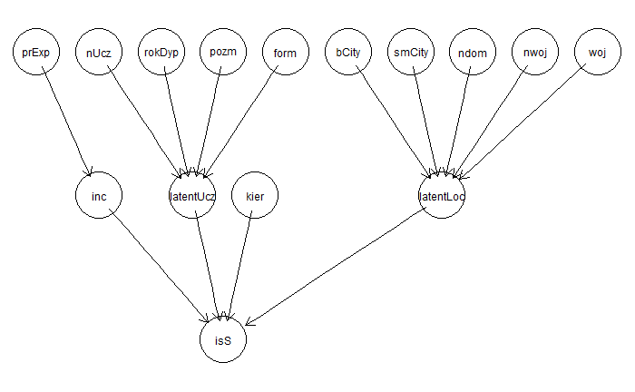

```r
smallerGraph = empty.graph(smallerColListWithLatent)
arcs(smallerGraph) = wlB
graphviz.plot(smallerGraph, layout = "dot")
```

```r
fitted = bn.fit(smallerGraph,dfLatent[smallerColListWithLatent],method = "bayes")
```

uzupelnienie wartosci brakujacych przy uzyciu grafu opracowanego powyzej w celu oceny istotnosci polaczen

```r
dfFilled<-impute(fitted,dfLatent[smallerColListWithLatent] )
```

```r
dfFilled
```

|  | nUcz | isS | rokDyp | pozm | form | prExp | inc | bCity | smCity | ndom | nwoj | kier | woj | latentLoc | latentUcz |
| --- | --- | --- | --- | --- | --- | --- | --- | --- | --- | --- | --- | --- | --- | --- | --- |
| 1 | [10,665] | (6.7,80] | [2014,2015] | 1 | N | (111,523] | (304921,1.6121e+006] | [0,1] | [0,6] | (6,11] | [0,10] | filologia | 12 | 3 | 1 |
| 2 | [10,665] | (1.5,6.7] | [2014,2015] | 1 | N | (523,995] | [385,192481] | [0,1] | [0,6] | (11,351] | [0,10] | pedagogika | 12 | 1 | 2 |
| 3 | [10,665] | (1.5,6.7] | [2014,2015] | 1 | N | (111,523] | [385,192481] | [0,1] | [0,6] | (11,351] | [0,10] | pedagogika | 12 | 2 | 3 |
| 4 | [10,665] | (6.7,80] | [2014,2015] | 1 | N | (523,995] | (192481,304921] | [0,1] | [0,6] | (11,351] | (10,26] | zarzadzanie | 12 | 3 | 2 |
| 5 | [10,665] | (1.5,6.7] | [2014,2015] | 1 | N | (523,995] | (304921,1.6121e+006] | [0,1] | [0,6] | [0,6] | (10,26] | filologia | 12 | 3 | 2 |
| 6 | [10,665] | (6.7,80] | [2014,2015] | 1 | N | (523,995] | (304921,1.6121e+006] | [0,1] | (6,21] | (11,351] | (10,26] | zarzadzanie | 12 | 3 | 2 |
| 7 | [10,665] | (6.7,80] | [2014,2015] | 1 | N | (523,995] | (304921,1.6121e+006] | (1,6] | (6,21] | (6,11] | (10,26] | budownictwo | 14 | 3 | 2 |
| 8 | [10,665] | (6.7,80] | [2014,2015] | 1 | N | (523,995] | (192481,304921] | (1,6] | (6,21] | (6,11] | (26,722] | budownictwo | 14 | 3 | 1 |
| 9 | [10,665] | (6.7,80] | [2014,2015] | 1 | N | (523,995] | [385,192481] | (6,372] | (6,21] | (6,11] | (26,722] | Dziedzina nauk spolecznych | 14 | 3 | 2 |
| 10 | [10,665] | (6.7,80] | (2017,2019] | 1 | N | [0,111] | (304921,1.6121e+006] | (1,6] | [0,6] | [0,6] | [0,10] | Dziedzina nauk spolecznych | 14 | 3 | 2 |

[output cut: 990 more lines]

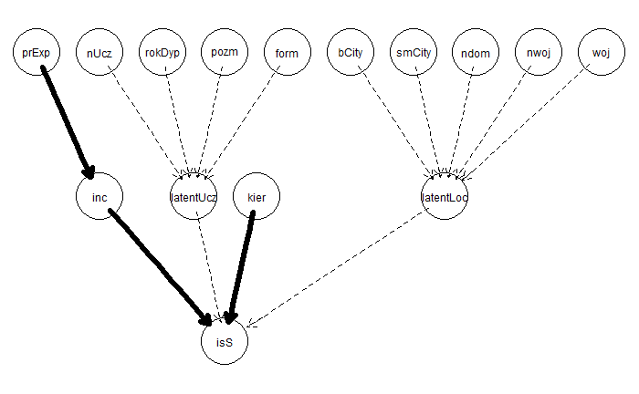

```r
#sens <- proportional_covar(bnfit = e, node = isS)
strength <- arc.strength(smallerGraph,dfFilled)
#plot(sens)
strength.plot(smallerGraph, strength)
```

bootstrap function for caclulating edge strenths - based on calculating p values

```r
arcs = boot.strength(dfFilled, algorithm = "hc")
```

```r
fromArches<-as_tibble(arcs)%>%arrange(desc(strength))%>%filter(from=='isS')%>%filter(strength>0.05)
toArches<-as_tibble(arcs)%>%arrange(desc(strength))%>%filter(to=='isS')%>%filter(strength>0.05)
toArches
```

| from | to | strength | direction |
| --- | --- | --- | --- |
| pozm | isS | 1.000 | 0.0900000 |
| form | isS | 1.000 | 0.8450000 |
| smCity | isS | 1.000 | 0.9100000 |
| ndom | isS | 1.000 | 0.9100000 |
| nwoj | isS | 1.000 | 0.0900000 |
| kier | isS | 1.000 | 0.0900000 |
| woj | isS | 0.820 | 1.0000000 |
| rokDyp | isS | 0.575 | 0.8434783 |
| bCity | isS | 0.540 | 0.8333333 |
| nUcz | isS | 0.065 | 1.0000000 |

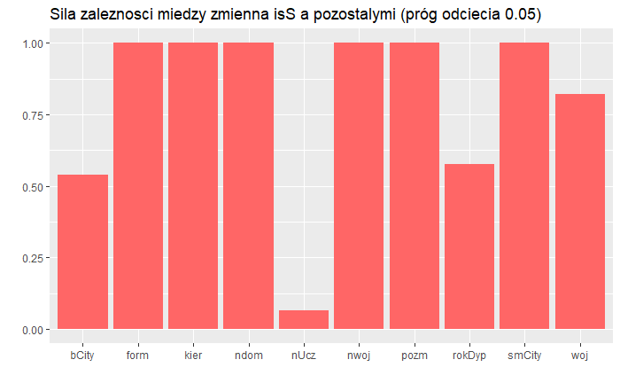

```r
ggplot(data=fromArches, aes(x=to, y=strength)) +
  geom_bar(stat="identity", fill = "#FF6666")+
  xlab("")+
  ylab(" ")+
  ggtitle("Siła zależności między zmienną isS a pozostałymi (próg odcięcia 0.05)")
```

```r
glob_net_monit <- final_node_monitor(dag = smallerGraph, df = dfFilled)
#glob_net_monit <- seq_marg_monitor(dag = e, df = df, node.name = 'isS')
glob_net_monit
```

| node | marg.z.score | cond.z.score |
| --- | --- | --- |
| nUcz | -9.679508 | -9.679727 |
| isS | -36.612167 | -36.609386 |
| rokDyp | -84.147394 | -84.136928 |
| pozm | -1.004400 | -1.004401 |
| form | -1.940409 | -1.940419 |
| prExp | -7.478852 | -7.478925 |
| inc | -10.337031 | -10.337175 |
| bCity | -3.788120 | -3.788155 |
| smCity | -1.141199 | -1.141202 |
| ndom | -2.846593 | -2.846613 |

[output cut: 5 more lines]

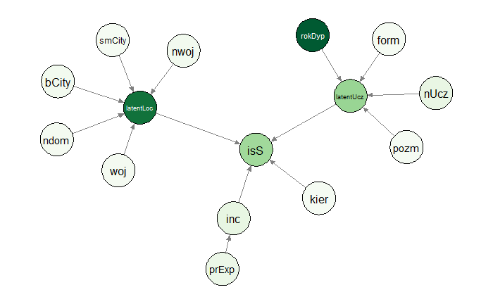

```r
plot(glob_net_monit,which="conditional" )
```

```r
#plot(glob_net_monit,which="marginal" )
```

Kolejna proba

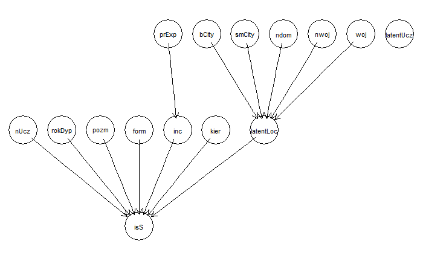

```r
smallerColListWithLatentC<- c("nUcz","isS", "rokDyp","pozm","form","prExp"
  ,"inc","bCity","smCity","ndom", "nwoj",  "kier", "woj","latentLoc", "latentUcz")

wlC = matrix(c("ndom","latentLoc"
               ,"nwoj","latentLoc"
               ,"latentLoc","isS"
               ,"bCity","latentLoc"
              ,"smCity","latentLoc"

              ,"prExp","inc"
              ,"inc","isS"
                ,"kier","isS"
              ,"nUcz","isS"
              ,"woj","latentLoc"

              ,"rokDyp","isS"
              ,"pozm","isS"
              ,"form","isS"

), ncol = 2, byrow = TRUE,
      dimnames = list(NULL, c("from", "to")))


smallerGraphC = empty.graph(smallerColListWithLatentC)
arcs(smallerGraphC) = wlC
graphviz.plot(smallerGraphC, layout = "dot")
```

```r
strengthC <- arc.strength(smallerGraphC,dfFilled)
#plot(sens)
strength.plot(smallerGraphC, strength)
```

[output not shown]

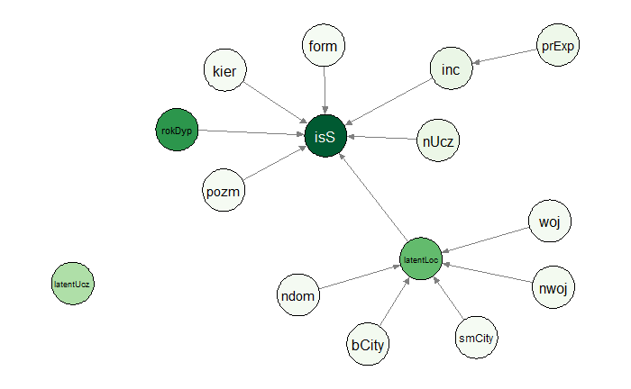

```r
glob_net_monitC <- final_node_monitor(dag = smallerGraphC, df = dfFilled)
plot(glob_net_monitC,which="conditional" )
```

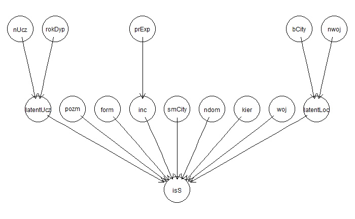

```r
smallerColListWithLatentD<- c("nUcz","isS", "rokDyp","pozm","form","prExp"
  ,"inc","bCity","smCity","ndom", "nwoj",  "kier", "woj","latentLoc", "latentUcz")

wlD = matrix(c(
                "ndom","isS"
               ,"nwoj","latentLoc"
               ,"latentLoc","isS"
               ,"bCity","latentLoc"
              ,"smCity","isS"

              ,"prExp","inc"
              ,"inc","isS"
                ,"kier","isS"
              ,"nUcz","latentUcz"
              ,"woj","isS"

              ,"rokDyp","latentUcz"
              ,"pozm","isS"
              ,"form","isS"
              ,"latentUcz","isS"

), ncol = 2, byrow = TRUE,
      dimnames = list(NULL, c("from", "to")))


smallerGraphD = empty.graph(smallerColListWithLatentD)
arcs(smallerGraphD) = wlD
graphviz.plot(smallerGraphD, layout = "dot")
```

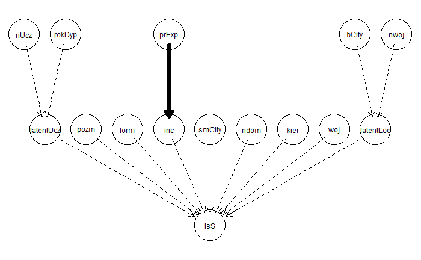

```r
strengthD <- arc.strength(smallerGraphD,dfFilled)
#plot(sens)
strength.plot(smallerGraphD, strengthD)
```

```r
pvalues = arc.strength(smallerGraphD,dfFilled, criterion = "x2")
pvalues
```

|  | from | to | strength |
| --- | --- | --- | --- |
| 1 | ndom | isS | 1.00000000 |
| 2 | nwoj | latentLoc | 0.28021724 |
| 3 | latentLoc | isS | 1.00000000 |
| 4 | bCity | latentLoc | 0.07666616 |
| 5 | smCity | isS | 1.00000000 |
| 6 | prExp | inc | 0.00000000 |
| 7 | inc | isS | 1.00000000 |
| 8 | kier | isS | 1.00000000 |
| 9 | nUcz | latentUcz | 0.63850586 |
| 10 | woj | isS | 1.00000000 |

[output cut: 4 more lines]

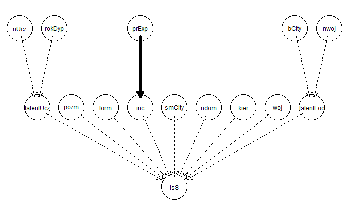

```r
strength.plot(smallerGraphD, strength = pvalues,threshold = 0.00001,cutpoints = c(0, 1e-300, 1e-250, 1e-200, 0.01, 1))
```

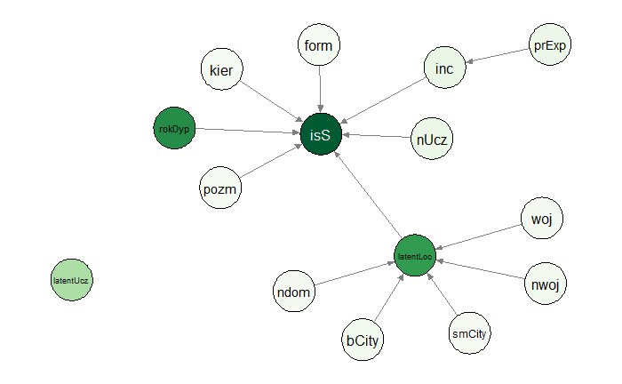

```r
glob_net_monitC <- final_node_monitor(dag = smallerGraphC, df = dfFilled)
plot(glob_net_monitC,which="conditional" )
```

# Porownanie modeli

```r
score(smallerGraphD,dfFilled)
```

[output not shown]